# Exercise Solution for Chapter 12

Amy Fox

## Exercise 12.2 from Modern Statistics for Modern Biologists

Use glmnet for a prediction of a continous variable, i.e., for regression. Use the prostate cancer data from Chapter 3 of (Hastie, Tibshirani, and Friedman 2008). The data are available in the CRAN package ElemStatLearn. Explore the effects of using ridge versus lasso penalty.

Here are the packages that need to be installed.

```r
# install.packages("glmnet")
library(dplyr)
library(glmnet)
library(ggplot2)
```

## Data for the exercise

The `ElemStatPackage` has been orphaned and isn’t on CRAN anymore. However, it’s up on GitHub, so I grabbed the data file you’ll need from there. You can download it yourself at: https://github.com/cran/ElemStatLearn/blob/master/data/prostate.RData

```r
load("../data/prostate.RData")

prostate %>%
  head()
```

```
##       lcavol  lweight age      lbph svi       lcp gleason pgg45       lpsa
## 1 -0.5798185 2.769459  50 -1.386294   0 -1.386294       6     0 -0.4307829
## 2 -0.9942523 3.319626  58 -1.386294   0 -1.386294       6     0 -0.1625189
## 3 -0.5108256 2.691243  74 -1.386294   0 -1.386294       7    20 -0.1625189
## 4 -1.2039728 3.282789  58 -1.386294   0 -1.386294       6     0 -0.1625189
## 5  0.7514161 3.432373  62 -1.386294   0 -1.386294       6     0  0.3715636
## 6 -1.0498221 3.228826  50 -1.386294   0 -1.386294       6     0  0.7654678
##   train
## 1  TRUE
## 2  TRUE
## 3  TRUE
## 4  TRUE
## 5  TRUE
## 6  TRUE
```

Here’s a description of the data, from the archived help files:

> “Data to examine the correlation between the level of prostate-specific antigen and a number of clinical measures in men who were about to receive a radical prostatectomy.”

Here’s what the variables mean:

- `lcavol`: log cancer volume
- `lweight`: log prostate weight
- `age`: in years
- `lbph`: log of the amount of benign prostatic hyperplasia
- `svi`: seminal vesicle invasion
- `lcp`: log of capsular penetration
- `gleason`: a numeric vector with the Gleason score
- `pgg45`: percent of Gleason score 4 or 5
- `lpsa`: response (the thing you are trying to predict), the level of prostate-specific antigen
- `train`: a logical vector, of whether the data was to be part of the training dataset (TRUE) or the testing one (FALSE)

So, you’re trying to predict the values of `lpsa` based on the variables `lcavol` through `pgg45`.

We will first split the data into testing and training data.

```r
prostate_train <- prostate %>%
  filter(train == TRUE)

prostate_test <- prostate %>%
  filter(train == FALSE)
```

There are 67 samples in the training set and 30 samples in the testing set.

## Fit generaltized linear model (glmnet) with Lasso and Ridge penalties

Here, we use a matrix of all of the predictors (`x`) to try to predict the `lpsa` column (`y`).

Based on the glmnet package, when alpha = 1 the lasso penalty is used, if alpha = 0, then ridge penalty is used. A great resource for the glmnet package can be found here: https://web.stanford.edu/~hastie/glmnet/glmnet_alpha.html

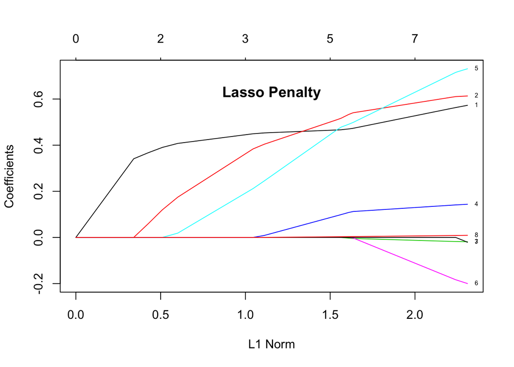

```r
# Lasso
lasso_glmnet <- glmnet(x = prostate_train %>% dplyr::select(lcavol:pgg45) %>% as.matrix(),
                    y = prostate_train %>% pull(lpsa),
                    family = "gaussian", alpha = 1)

plot(lasso_glmnet, label = TRUE)
title("Lasso Penalty", line = -2.5)
```

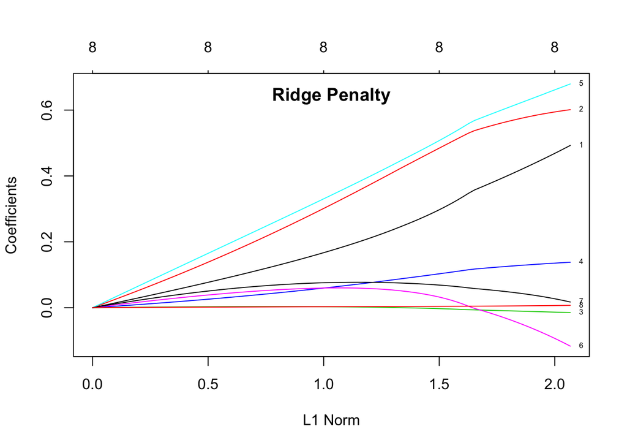

```r
# Ridge
ridge_glmnet <- glmnet(x = prostate_train %>% dplyr::select(lcavol:pgg45) %>% as.matrix(),
                    y = prostate_train %>% pull(lpsa),
                    family = "gaussian", alpha = 0)

plot(ridge_glmnet, label = TRUE)
title("Ridge Penalty", line = -1.5)
```

In the plots show the coefficients as L1- norm increases. The top axis shows the number of nonzero coefficients correspoding to the lamba at the current L1 norm. From these plots we can see that predictors 1, 2, and 5 are good predictors for the lpsa response.

## Cross Validation

We then want to perform cross-validation on the dataset. We use the cv.glmnet function to do this.

```r
set.seed(2)

# Lasso
cvglmnet_lasso <- cv.glmnet(x = prostate_train %>% dplyr::select(lcavol:pgg45) %>% as.matrix(),
                    y = prostate_train %>% pull(lpsa),
                    family = "gaussian", alpha = 0)
cvglmnet_lasso
```

```
##
## Call:  cv.glmnet(x = prostate_train %>% dplyr::select(lcavol:pgg45) %>%      as.matrix(), y = prostate_train %>% pull(lpsa), family = "gaussian",      alpha = 0)
##
## Measure: Mean-Squared Error
##
##     Lambda Measure      SE Nonzero
## min 0.0879  0.5939 0.09857       8
## 1se 0.9873  0.6873 0.08098       8
```

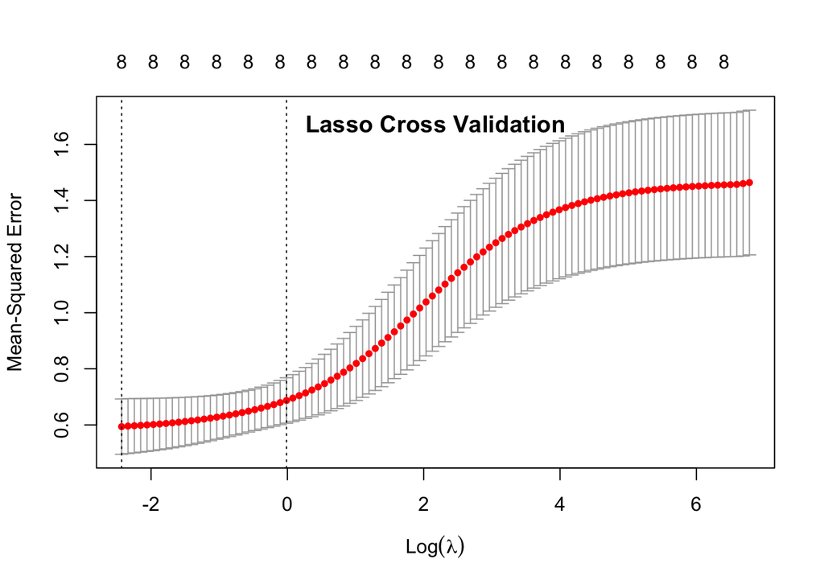

```r
plot(cvglmnet_lasso)
title("Lasso Cross Validation", line = -1.5)
```

```r
# Ridge
cvglmnet_ridge <- cv.glmnet(x = prostate_train %>% dplyr::select(lcavol:pgg45) %>% as.matrix(),
                    y = prostate_train %>% pull(lpsa),
                    family = "gaussian", alpha = 1)
cvglmnet_ridge
```

```
##
## Call:  cv.glmnet(x = prostate_train %>% dplyr::select(lcavol:pgg45) %>%      as.matrix(), y = prostate_train %>% pull(lpsa), family = "gaussian",      alpha = 1)
##
## Measure: Mean-Squared Error
##
##      Lambda Measure      SE Nonzero
## min 0.01336  0.5753 0.07244       7
## 1se 0.13673  0.6408 0.09222       5
```

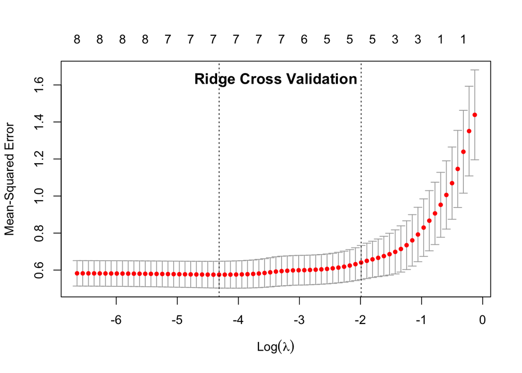

```r
plot(cvglmnet_ridge)
title("Ridge Cross Validation", line = -1.5)
```

## Lasso Prediction

We start by using the `predict` function to use the model to predict the lpsa on the testing data. We can then see the correlation between the predicted values and actual values.

```r
s0 <- cvglmnet_lasso$lambda.1se

lasso_predict <- predict(cvglmnet_lasso, newx = prostate_test%>% dplyr::select(lcavol:pgg45) %>% as.matrix(), s = s0)

# create a data frame of the actual lpsa values and the predicted lpsa values
actual_lasso_predict_df <- data.frame(prediction = as.vector(lasso_predict), actual = prostate_test$lpsa)
```

We can then see how correlated the prediction and real data are.

```r
# look at the correlation of the prediction and real data
cor(actual_lasso_predict_df)
```

```
##            prediction    actual
## prediction  1.0000000 0.7277086
## actual      0.7277086 1.0000000
```

They are 72% correlated.

We can then fit a linear line to the prediction and actual data and look at the r^2 value

```r
lm(actual_lasso_predict_df) %>%
  summary()
```

```
##
## Call:
## lm(formula = actual_lasso_predict_df)
##
## Residuals:
##      Min       1Q   Median       3Q      Max
## -0.80115 -0.24539 -0.05877  0.24141  0.93424
##
## Coefficients:
##             Estimate Std. Error t value Pr(>|t|)
## (Intercept)  1.40143    0.20585   6.808 2.14e-07 ***
## actual       0.42246    0.07525   5.614 5.19e-06 ***
## ---
## Signif. codes:  0 '***' 0.001 '**' 0.01 '*' 0.05 '.' 0.1 ' ' 1
##
## Residual standard error: 0.4223 on 28 degrees of freedom
## Multiple R-squared:  0.5296, Adjusted R-squared:  0.5128
## F-statistic: 31.52 on 1 and 28 DF,  p-value: 5.194e-06
```

The adjusted r<sup>2</sup> value = 0.513

Finally, we can plot the actual vs. predicted values on a scatter plot. If the actual and predicted values matched up exactly, they would sit on the y = x line.

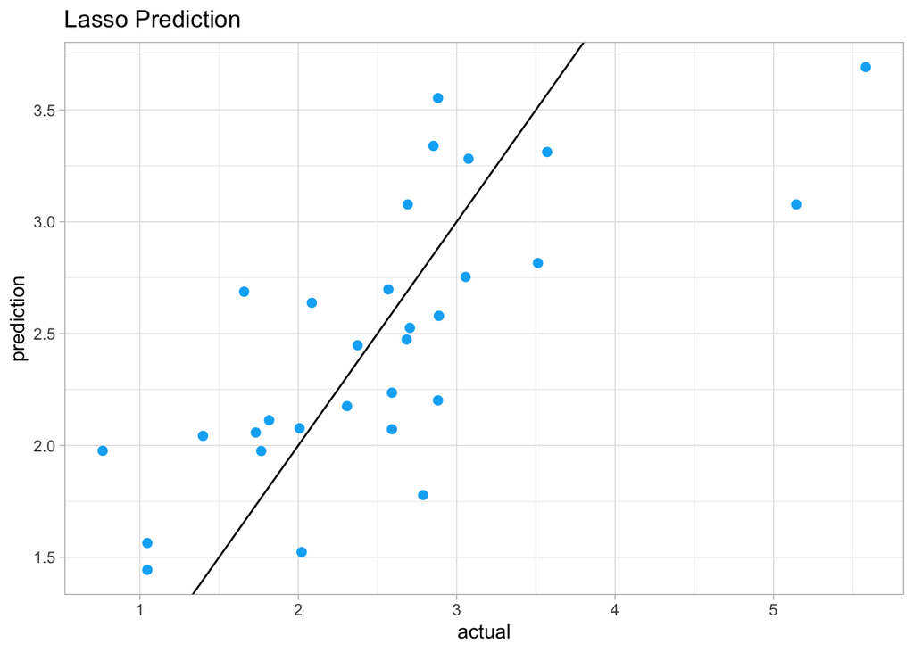

```r
ggplot(actual_lasso_predict_df, aes(x = actual, y = prediction)) +
  geom_point(color = "#00B0F6", size = 2) +
  geom_abline(slope=1, intercept=0)+
  ggtitle("Lasso Prediction") +
  theme_light()
```

## Ridge Prediction

```r
s0 <- cvglmnet_ridge$lambda.1se

ridge_predict <- predict(cvglmnet_ridge, newx = prostate_test%>% dplyr::select(lcavol:pgg45) %>% as.matrix(), s = s0)

prostate_test$lpsa
```

```
##  [1] 0.7654678 1.0473190 1.0473190 1.3987169 1.6582281 1.7316555 1.7664417
##  [8] 1.8164521 2.0082140 2.0215476 2.0856721 2.3075726 2.3749058 2.5687881
## [15] 2.5915164 2.5915164 2.6844403 2.6912431 2.7047113 2.7880929 2.8535925
## [22] 2.8820035 2.8820035 2.8875901 3.0563569 3.0750055 3.5130369 3.5709402
## [29] 5.1431245 5.5829322
```

```r
actual_ridge_predict_df <- data.frame(prediction = as.vector(ridge_predict), actual = prostate_test$lpsa)
```

We can then see how correlated the prediction and real data are.

```r
cor(actual_ridge_predict_df)
```

```
##            prediction    actual
## prediction  1.0000000 0.7765403
## actual      0.7765403 1.0000000
```

The ridge prediction and acutal values are 77% correlated.

We can then fit a linear line to the prediction and actual data and look at the r^2 value

```r
lm(actual_ridge_predict_df) %>%
  summary()
```

```
##
## Call:
## lm(formula = actual_ridge_predict_df)
##
## Residuals:
##     Min      1Q  Median      3Q     Max
## -0.8438 -0.2155 -0.0225  0.2252  0.6732
##
## Coefficients:
##             Estimate Std. Error t value Pr(>|t|)
## (Intercept)  1.33258    0.19271   6.915 1.62e-07 ***
## actual       0.45941    0.07044   6.522 4.55e-07 ***
## ---
## Signif. codes:  0 '***' 0.001 '**' 0.01 '*' 0.05 '.' 0.1 ' ' 1
##
## Residual standard error: 0.3953 on 28 degrees of freedom
## Multiple R-squared:  0.603,  Adjusted R-squared:  0.5888
## F-statistic: 42.53 on 1 and 28 DF,  p-value: 4.551e-07
```

The adjusted r<sup>2</sup> value = 0.589

Finally, we can plot the actual vs. predicted values on a scatter plot. If the actual and predicted values matched up exactly, they would sit on the y = x line.

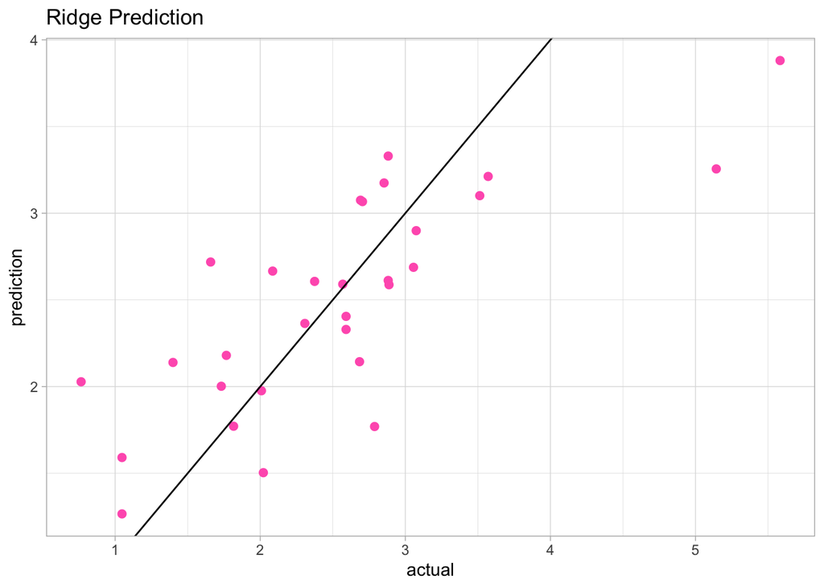

```r
ggplot(actual_ridge_predict_df, aes(x = actual, y = prediction)) +
  geom_point(color = "#FF62BC", size = 2) +
  geom_abline(slope=1, intercept=0) +
  ggtitle("Ridge Prediction") +
  theme_light()
```